# Научная презентация

Дисциплина:Операционные системы

Абрамова У. М.

Российский университет дружбы народов, Москва, Россия

Математический институт имени Никольского, Москва, Россия

15.03.2025

# Информация

## Докладчик

- Абрамова Ульяна Михайловна
- Студент НММбд-01-24
- Российский университет дружбы народов
- 1132246782@pfur.ru
- https://github.com/Ulyana-abr

# Вводная часть

## Актуальность

- Благодаря chezmoi и pass удобно работать на нескольких виртуальных машинах в одной системе.

## Цели и задачи

- Научиться работать с pass и chezmoi

## Материалы и методы

Устанавливаю pass и gopass (рис.1,2)

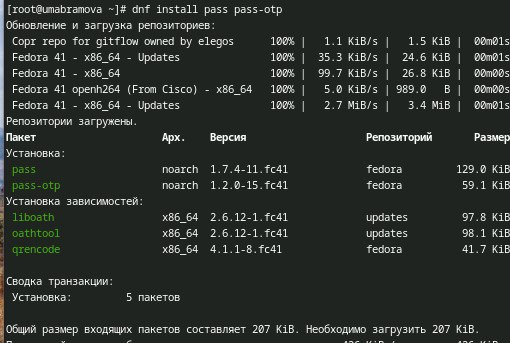

установка pass

## Содержание исследования

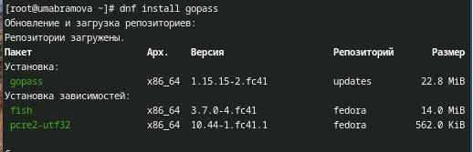

установка gopass

## Содержание исследования

Просматриваю список ключей (рис.3)

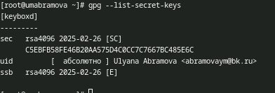

просмотр списка ключей

## Содержание исследования

Инициализирую хранилище (рис.4)

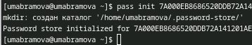

инициализация хранилища

## Содержание исследования

Создаю структуру git (рис.5)

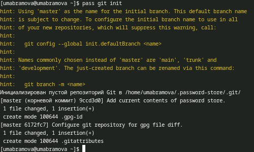

создание структуры

## Содержание исследования

Создаю новый репозиторий, задаю адрес репрозитория на хостинге, и затем выполняю синхронизацию (рис.6)

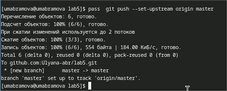

создание и синхронизация нового репрозитория

## Содержание исследования

Устанавливаю browserpass (рис.7)

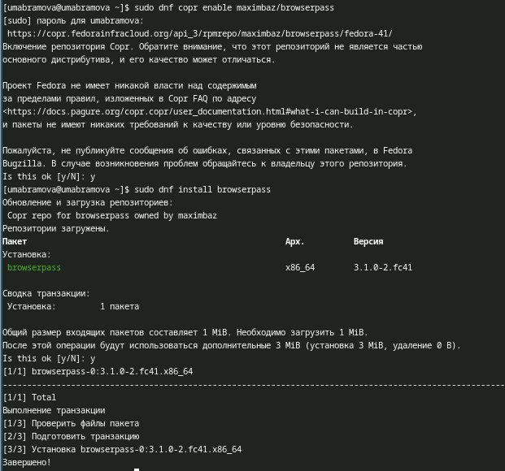

установка browserpass

## Содержание исследования

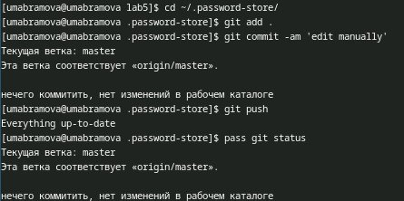

## Содержание исследования

Устанавливаю по и шрифты (рис.9, 10)

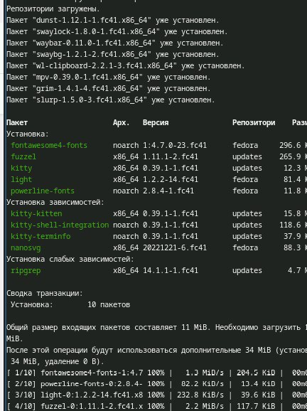

установка необходимого по

## Содержание исследования

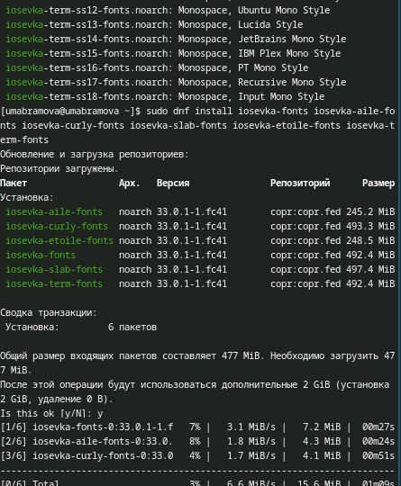

установка шрифтов

## Содержание исследования

Устанавливаю chezmoi и создаю свой репозиторий для конфигурационных файлов на основе шаблона (рис.11, 12)

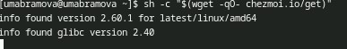

установка chezmoi

## Содержание исследования

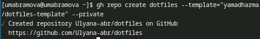

создание репозитория

## Содержание исследования

Подключаю репозиторий к своей системе (рис.13)

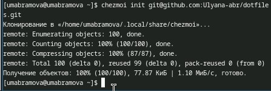

подключение репозитория

## Содержание исследования

Проверяю внесённые изменения и соглашаюсь с ними (рис.14)

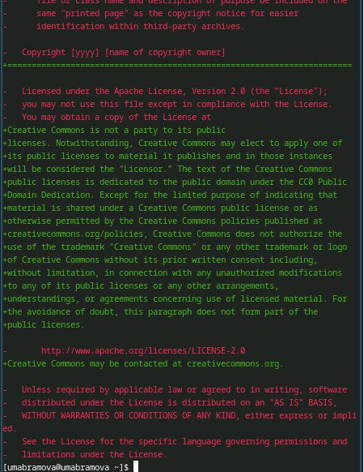

просмотр внесенных изменений

## Содержание исследования

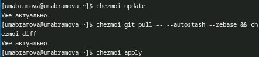

извлечение последних изменений

## Результаты

- В результате я выполнила настройку интерфейса с броузером, произвела управление файлами конфигурации и использовала chezmoi

## Итоговый слайд

- Чем больше вы практикуетесь и пробуете новое, тем больше и чаще вы будете получать знаний и опыта в разных сферах.